# Module 37

#### Hemi-module gene counts:

344 probesets in hemi-module A.  
15 probesets in hemi-module B.  
Note: While the mapping of probesets to genes is usually one-to-one, some genes are targeted by multiple probesets, some probesets target multiple genes, and some probesets do not target any genes (i.e., the region of the genome they match is no longer considered genic).

#### Contrast SVE:

Signed variance explained (SVE) provides an indication of how similar a set of fold changes are to a gene module’s weight vector. An SVE value of 0.3, for example, indicates that 30% of the variance explained by the entire module set is accounted for by the module in question. Shown here are the SVE values for this module across a compendium of fold changes (contrasts). Extreme SVE values (e.g., > 0.05) indicate that those contrasts specifically induce (orange dots) or specifically repress (blue dots) this module. Examining the experimental conditions being compared in such contrasts (see tables below the figure) may provide insight into the gene module’s function.

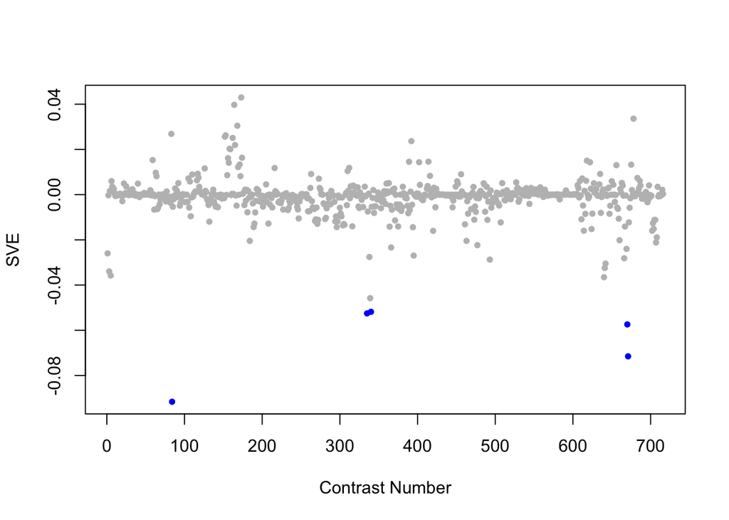

Positive SVE Contrasts:

|  | Contrast.Num | SVE | GEO.GSE | Cond.1 | Cond.2 | Mutation |
| --- | --- | --- | --- | --- | --- | --- |
| GSE47778.s1t3.vs.s4t3 | 173 | 0.04 | GSE47778 | N2; UV; replicate 1 | daf-2;daf-16; UV; replicate 1 | daf-2;daf-16 |
| GSE47778.s1t2.vs.s2t2 | 164 | 0.04 | GSE47778 | N2; starvation; replicate 1 | daf-2; starvation; replicate 1 | daf-2 |
| GSE13258.s1t1.vs.s0t1 | 678 | 0.03 | GSE13258 | zfp-1 mutant, biological rep 1 | wild-type, biological rep 1 | zfp-1 |
| GSE47778.s1t3.vs.s3t3 | 168 | 0.03 | GSE47778 | N2; UV; replicate 1 | daf-16; UV; replicate 1 | daf-16 |
| GSE6563.s1t1.vs.s0t1 | 83 | 0.03 | GSE6563 | daf19(m86)_daf12(sa204) replicate 1 | daf19(WT)_daf12(sa204) replicate 1 | daf-19 |

Negative SVE Contrasts:

|  | Contrast.Num | SVE | GEO.GSE | Cond.1 | Cond.2 | Mutation |
| --- | --- | --- | --- | --- | --- | --- |
| GSE6547.s2t2.vs.s0t2 | 84 | -0.09 | GSE6547 | slr-2(ku297) worms at L1 stage, first replicate | N2 (wt) worms at L1 stage, first replicate | sir-2 |
| GSE15016.s1t1.vs.s0t1 | 671 | -0.07 | GSE15016 | young adult_24hr AgNPs exposure_rep1 | young adult_not exposured_rep1 |  |
| GSE15016.s2t1.vs.s0t1 | 670 | -0.06 | GSE15016 | young adult_24hr NP exposure_rep1 | young adult_not exposured_rep1 |  |
| GSE38997.s3t2.vs.s2t2 | 335 | -0.05 | GSE38997 | experiment 4 UVC- and EtBr-exposed samples at 24 h 4eu24 | experiment 4 EtBr-exposed samples at 24 h 4e24 |  |
| GSE38997.s4t1.vs.s1t1 | 340 | -0.05 | GSE38997 | experiment 4 UVC-exposed samples at 3 h 4u3 | experiment 4 control samples at 3 h 4c3 |  |

$~$

#### Contrast SVE, Up-Regulated Genes Only:

Calculating SVE for up-regulated and down-regulated genes separately may be more informative in many cases than projecting the up- and down- gene sets together. This is due to the fact that the weight distribution of many modules is highly skewed, indicating that only one of the hemi-modules may be biologically meaningful (i.e., a set of genes are strongly correlated by only a few genes (or none) are strongly anti-correlated to that set.)

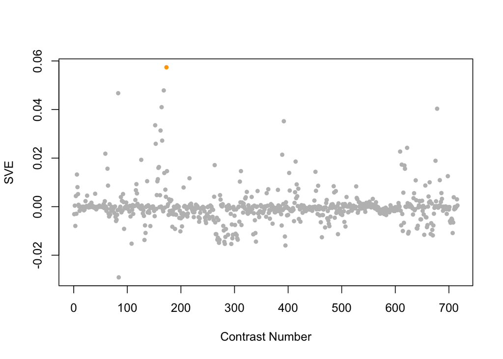

Positive SVE Contrasts:

|  | Contrast.Num | SVE | GEO.GSE | Cond.1 | Cond.2 | Mutation |
| --- | --- | --- | --- | --- | --- | --- |
| GSE47778.s1t3.vs.s4t3 | 173 | 0.06 | GSE47778 | N2; UV; replicate 1 | daf-2;daf-16; UV; replicate 1 | daf-2;daf-16 |
| GSE47778.s1t3.vs.s3t3 | 168 | 0.05 | GSE47778 | N2; UV; replicate 1 | daf-16; UV; replicate 1 | daf-16 |
| GSE6563.s1t1.vs.s0t1 | 83 | 0.05 | GSE6563 | daf19(m86)_daf12(sa204) replicate 1 | daf19(WT)_daf12(sa204) replicate 1 | daf-19 |
| GSE47778.s1t2.vs.s2t2 | 164 | 0.04 | GSE47778 | N2; starvation; replicate 1 | daf-2; starvation; replicate 1 | daf-2 |
| GSE13258.s1t1.vs.s0t1 | 678 | 0.04 | GSE13258 | zfp-1 mutant, biological rep 1 | wild-type, biological rep 1 | zfp-1 |

Negative SVE Contrasts:

|  | Contrast.Num | SVE | GEO.GSE | Cond.1 | Cond.2 | Mutation |
| --- | --- | --- | --- | --- | --- | --- |
| GSE6547.s2t2.vs.s0t2 | 84 | -0.03 | GSE6547 | slr-2(ku297) worms at L1 stage, first replicate | N2 (wt) worms at L1 stage, first replicate | sir-2 |
| GSE32339.s0t2.vs.s0t1 | 395 | -0.02 | GSE32339 | Adult Wild-type, biological rep1 | Larval Wild-type, biological rep1 |  |
| GSE41366C.s1t3.vs.s0t3 | 294 | -0.02 | GSE41366 | low_DDVP-continuous_expose-14h_harvest-rep1 | control-continuous_expose-8h_harvest-rep1 |  |
| GSE41366B.s2t3.vs.s2t1 | 282 | -0.02 | GSE41366 | high_DDVP-8h_expose-26h_harvest-rep1 | high_DDVP-8h_expose-14h_harvest-rep1 |  |
| GSE54513.s3t1.vs.s2t1 | 108 | -0.02 | GSE54513 | spe-9 input rep1 | fog-1 OMA-1 IP rep1 |  |

$~$

#### Contrast SVE, Down-Regulated Genes Only:

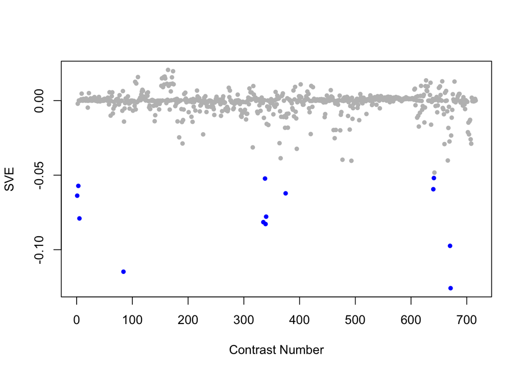

Positive SVE Contrasts:

|  | Contrast.Num | SVE | GEO.GSE | Cond.1 | Cond.2 | Mutation |
| --- | --- | --- | --- | --- | --- | --- |
| GSE47778.s1t2.vs.s2t2 | 164 | 0.02 | GSE47778 | N2; starvation; replicate 1 | daf-2; starvation; replicate 1 | daf-2 |
| GSE47778.s1t3.vs.s4t3 | 173 | 0.02 | GSE47778 | N2; UV; replicate 1 | daf-2;daf-16; UV; replicate 1 | daf-2;daf-16 |
| GSE47778.s5t1.vs.s4t1 | 158 | 0.02 | GSE47778 | xpa-1 0mJ/cm2; replicate 1 | daf-2;daf-16; replicate 1 | xpa-1 vs. daf-2;daf-16 |
| GSE54513.s4t1.vs.s3t1 | 110 | 0.02 | GSE54513 | spe-9 OMA-1 IP rep1 | spe-9 input rep1 |  |
| GSE47778.s5t1.vs.s2t1 | 156 | 0.02 | GSE47778 | xpa-1 0mJ/cm2; replicate 1 | daf-2; replicate 1 | xpa-1 vs. daf-2 |

Negative SVE Contrasts:

|  | Contrast.Num | SVE | GEO.GSE | Cond.1 | Cond.2 | Mutation |
| --- | --- | --- | --- | --- | --- | --- |
| GSE15016.s1t1.vs.s0t1 | 671 | -0.13 | GSE15016 | young adult_24hr AgNPs exposure_rep1 | young adult_not exposured_rep1 |  |
| GSE6547.s2t2.vs.s0t2 | 84 | -0.11 | GSE6547 | slr-2(ku297) worms at L1 stage, first replicate | N2 (wt) worms at L1 stage, first replicate | sir-2 |
| GSE15016.s2t1.vs.s0t1 | 670 | -0.10 | GSE15016 | young adult_24hr NP exposure_rep1 | young adult_not exposured_rep1 |  |
| GSE38997.s3t1.vs.s1t1 | 339 | -0.08 | GSE38997 | experiment 4 UVC- and EtBr-exposed samples at 3 h 4eu3 | experiment 4 control samples at 3 h 4c3 |  |
| GSE38997.s3t2.vs.s2t2 | 335 | -0.08 | GSE38997 | experiment 4 UVC- and EtBr-exposed samples at 24 h 4eu24 | experiment 4 EtBr-exposed samples at 24 h 4e24 |  |
| GSE9897B.s2t1.vs.s0t1 | 5 | -0.08 | GSE9897 | Complex I RNAi Mutant 2 | Wildtype (control for RNAi) | Y45G12B.1 |
| GSE38997.s4t1.vs.s1t1 | 340 | -0.08 | GSE38997 | experiment 4 UVC-exposed samples at 3 h 4u3 | experiment 4 control samples at 3 h 4c3 |  |
| GSE9897A.s1t1.vs.s0t1 | 1 | -0.06 | GSE9897 | Complex I missense mutant | Wildtype (control for missense) | gas-1 |
| GSE35354A.s1t2.vs.s1t1 | 375 | -0.06 | GSE35354 | Q50_rep1 | Q control_rep1 |  |
| GSE18132.s2t2.vs.s2t1 | 640 | -0.06 | GSE18132 | Oga Fed L4, biological replicate 1 | Oga starved L1, biological replicate 1 |  |
| GSE9897A.s3t1.vs.s0t1 | 3 | -0.06 | GSE9897 | Complex III missense mutant | Wildtype (control for missense) | isp-1 |
| GSE38997.s2t1.vs.s1t1 | 338 | -0.05 | GSE38997 | experiment 4 EtBr-exposed samples at 3 h 4e3 | experiment 4 control samples at 3 h 4c3 |  |
| GSE18132.s1t2.vs.s1t1 | 641 | -0.05 | GSE18132 | Ogt Fed L4, biological replicate 1 | Ogt starved L1, biological replicate 1 |  |

$~$

$~$

#### GO Term Enrichment:

This analysis tests each hemi-module for enrichment of specific GO terms. Only gene-level annotations (e.g., as would be found on the gene’s page in Wormbase) are tested - the hierarchical structure of the GO ontology is not taken into account.

*Note: At least the top two most enriched terms from each GO domain (BP/MF/CC) are shown, even when not statistically significant.*

##### Enriched GO terms: Hemi-module A

| ID | GO.Term | GO Domain | Raw p-value | Adj p-value |
| --- | --- | --- | --- | --- |
| [GO_0006811](http://amigo.geneontology.org/amigo/term/GO:0006811) | ion transport | BP | 3.33e-08 | 8.34e-05 |
| [GO_0043051](http://amigo.geneontology.org/amigo/term/GO:0043051) | regulation of pharyngeal pumping | BP | 4.58e-08 | 8.34e-05 |
| [GO_0007165](http://amigo.geneontology.org/amigo/term/GO:0007165) | signal transduction | BP | 1.80e-07 | 2.18e-04 |
| [GO_0040017](http://amigo.geneontology.org/amigo/term/GO:0040017) | positive regulation of locomotion | BP | 2.49e-07 | 2.27e-04 |
| [GO_0006816](http://amigo.geneontology.org/amigo/term/GO:0006816) | calcium ion transport | BP | 1.95e-06 | 1.42e-03 |
| [GO_1900194](http://amigo.geneontology.org/amigo/term/GO:1900194) | negative regulation of oocyte maturation | BP | 2.95e-06 | 1.79e-03 |
| [GO_0030154](http://amigo.geneontology.org/amigo/term/GO:0030154) | cell differentiation | BP | 1.01e-05 | 5.24e-03 |
| [GO_2000114](http://amigo.geneontology.org/amigo/term/GO:2000114) | regulation of establishment of cell polarity | BP | 2.35e-05 | 1.07e-02 |
| [GO_0045214](http://amigo.geneontology.org/amigo/term/GO:0045214) | sarcomere organization | BP | 2.92e-05 | 1.18e-02 |
| [GO_0070509](http://amigo.geneontology.org/amigo/term/GO:0070509) | calcium ion import | BP | 3.79e-05 | 1.38e-02 |
| [GO_0006357](http://amigo.geneontology.org/amigo/term/GO:0006357) | regulation of transcription by RNA polymerase II | BP | 4.22e-05 | 1.40e-02 |
| [GO_0070588](http://amigo.geneontology.org/amigo/term/GO:0070588) | calcium ion transmembrane transport | BP | 6.11e-05 | 1.86e-02 |
| [GO_1902474](http://amigo.geneontology.org/amigo/term/GO:1902474) | positive regulation of protein localization to synapse | BP | 9.33e-05 | 2.61e-02 |
| [GO_0006355](http://amigo.geneontology.org/amigo/term/GO:0006355) | regulation of transcription, DNA-templated | BP | 1.74e-04 | 4.46e-02 |
| [GO_0032224](http://amigo.geneontology.org/amigo/term/GO:0032224) | positive regulation of synaptic transmission, cholinergic | BP | 1.84e-04 | 4.46e-02 |
| [GO_0043401](http://amigo.geneontology.org/amigo/term/GO:0043401) | steroid hormone mediated signaling pathway | BP | 2.15e-04 | 4.88e-02 |
| [GO_0007275](http://amigo.geneontology.org/amigo/term/GO:0007275) | multicellular organism development | BP | 2.41e-04 | 4.88e-02 |
| [GO_0016310](http://amigo.geneontology.org/amigo/term/GO:0016310) | phosphorylation | BP | 2.41e-04 | 4.88e-02 |
| [GO_0090038](http://amigo.geneontology.org/amigo/term/GO:0090038) | negative regulation of protein kinase C signaling | BP | 3.16e-04 | 6.07e-02 |
| [GO_0006874](http://amigo.geneontology.org/amigo/term/GO:0006874) | cellular calcium ion homeostasis | BP | 3.89e-04 | 6.23e-02 |
| [GO_0042493](http://amigo.geneontology.org/amigo/term/GO:0042493) | response to drug | BP | 3.89e-04 | 6.23e-02 |
| [GO_0006468](http://amigo.geneontology.org/amigo/term/GO:0006468) | protein phosphorylation | BP | 3.96e-04 | 6.23e-02 |
| [GO_0010960](http://amigo.geneontology.org/amigo/term/GO:0010960) | magnesium ion homeostasis | BP | 4.54e-04 | 6.23e-02 |
| [GO_0032793](http://amigo.geneontology.org/amigo/term/GO:0032793) | positive regulation of CREB transcription factor activity | BP | 4.54e-04 | 6.23e-02 |
| [GO_0051489](http://amigo.geneontology.org/amigo/term/GO:0051489) | regulation of filopodium assembly | BP | 4.54e-04 | 6.23e-02 |
| [GO_1905484](http://amigo.geneontology.org/amigo/term/GO:1905484) | negative regulation of motor neuron migration | BP | 4.54e-04 | 6.23e-02 |
| [GO_0040018](http://amigo.geneontology.org/amigo/term/GO:0040018) | positive regulation of multicellular organism growth | BP | 4.62e-04 | 6.23e-02 |
| [GO_0046662](http://amigo.geneontology.org/amigo/term/GO:0046662) | regulation of oviposition | BP | 5.18e-04 | 6.74e-02 |
| [GO_0035545](http://amigo.geneontology.org/amigo/term/GO:0035545) | determination of left/right asymmetry in nervous system | BP | 7.36e-04 | 9.13e-02 |
| [GO_0007626](http://amigo.geneontology.org/amigo/term/GO:0007626) | locomotory behavior | BP | 7.52e-04 | 9.13e-02 |
| [GO_0005515](http://amigo.geneontology.org/amigo/term/GO:0005515) | protein binding | MF | 2.57e-08 | 5.24e-05 |
| [GO_0046872](http://amigo.geneontology.org/amigo/term/GO:0046872) | metal ion binding | MF | 2.10e-07 | 2.14e-04 |
| [GO_0005089](http://amigo.geneontology.org/amigo/term/GO:0005089) | Rho guanyl-nucleotide exchange factor activity | MF | 2.95e-06 | 2.01e-03 |
| [GO_0005509](http://amigo.geneontology.org/amigo/term/GO:0005509) | calcium ion binding | MF | 1.35e-05 | 5.92e-03 |
| [GO_0000977](http://amigo.geneontology.org/amigo/term/GO:0000977) | RNA polymerase II regulatory region sequence-specific DNA binding | MF | 1.45e-05 | 5.92e-03 |
| [GO_0000981](http://amigo.geneontology.org/amigo/term/GO:0000981) | DNA-binding transcription factor activity, RNA polymerase II-specific | MF | 2.45e-05 | 8.34e-03 |
| [GO_0043565](http://amigo.geneontology.org/amigo/term/GO:0043565) | sequence-specific DNA binding | MF | 4.85e-05 | 1.42e-02 |
| [GO_0017048](http://amigo.geneontology.org/amigo/term/GO:0017048) | Rho GTPase binding | MF | 5.96e-05 | 1.52e-02 |
| [GO_0003677](http://amigo.geneontology.org/amigo/term/GO:0003677) | DNA binding | MF | 6.94e-05 | 1.58e-02 |
| [GO_0004115](http://amigo.geneontology.org/amigo/term/GO:0004115) | 3’,5’-cyclic-AMP phosphodiesterase activity | MF | 9.33e-05 | 1.91e-02 |
| [GO_0004683](http://amigo.geneontology.org/amigo/term/GO:0004683) | calmodulin-dependent protein kinase activity | MF | 1.84e-04 | 2.99e-02 |
| [GO_0016301](http://amigo.geneontology.org/amigo/term/GO:0016301) | kinase activity | MF | 1.85e-04 | 2.99e-02 |
| [GO_0004672](http://amigo.geneontology.org/amigo/term/GO:0004672) | protein kinase activity | MF | 1.90e-04 | 2.99e-02 |
| [GO_0003707](http://amigo.geneontology.org/amigo/term/GO:0003707) | steroid hormone receptor activity | MF | 2.15e-04 | 3.14e-02 |
| [GO_0005216](http://amigo.geneontology.org/amigo/term/GO:0005216) | ion channel activity | MF | 2.31e-04 | 3.14e-02 |
| [GO_0000166](http://amigo.geneontology.org/amigo/term/GO:0000166) | nucleotide binding | MF | 2.62e-04 | 3.34e-02 |
| [GO_0004114](http://amigo.geneontology.org/amigo/term/GO:0004114) | 3’,5’-cyclic-nucleotide phosphodiesterase activity | MF | 3.16e-04 | 3.80e-02 |
| [GO_0044325](http://amigo.geneontology.org/amigo/term/GO:0044325) | ion channel binding | MF | 4.54e-04 | 4.85e-02 |
| [GO_0070016](http://amigo.geneontology.org/amigo/term/GO:0070016) | armadillo repeat domain binding | MF | 4.54e-04 | 4.85e-02 |
| [GO_0005245](http://amigo.geneontology.org/amigo/term/GO:0005245) | voltage-gated calcium channel activity | MF | 4.98e-04 | 4.85e-02 |
| [GO_0031435](http://amigo.geneontology.org/amigo/term/GO:0031435) | mitogen-activated protein kinase kinase kinase binding | MF | 4.98e-04 | 4.85e-02 |
| [GO_0005085](http://amigo.geneontology.org/amigo/term/GO:0005085) | guanyl-nucleotide exchange factor activity | MF | 6.47e-04 | 5.76e-02 |
| [GO_0005524](http://amigo.geneontology.org/amigo/term/GO:0005524) | ATP binding | MF | 6.49e-04 | 5.76e-02 |
| [GO_0005886](http://amigo.geneontology.org/amigo/term/GO:0005886) | plasma membrane | CC | 1.09e-13 | 1.01e-10 |
| [GO_0030424](http://amigo.geneontology.org/amigo/term/GO:0030424) | axon | CC | 2.65e-10 | 1.23e-07 |
| [GO_0045202](http://amigo.geneontology.org/amigo/term/GO:0045202) | synapse | CC | 2.64e-09 | 8.17e-07 |
| [GO_0030054](http://amigo.geneontology.org/amigo/term/GO:0030054) | cell junction | CC | 5.17e-09 | 1.20e-06 |
| [GO_0042995](http://amigo.geneontology.org/amigo/term/GO:0042995) | cell projection | CC | 1.35e-05 | 2.51e-03 |
| [GO_0031430](http://amigo.geneontology.org/amigo/term/GO:0031430) | M band | CC | 3.46e-05 | 5.35e-03 |
| [GO_0005887](http://amigo.geneontology.org/amigo/term/GO:0005887) | integral component of plasma membrane | CC | 1.06e-04 | 1.41e-02 |
| [GO_0016327](http://amigo.geneontology.org/amigo/term/GO:0016327) | apicolateral plasma membrane | CC | 4.54e-04 | 4.62e-02 |
| [GO_0098831](http://amigo.geneontology.org/amigo/term/GO:0098831) | presynaptic active zone cytoplasmic component | CC | 4.54e-04 | 4.62e-02 |
| [GO_0005891](http://amigo.geneontology.org/amigo/term/GO:0005891) | voltage-gated calcium channel complex | CC | 4.98e-04 | 4.62e-02 |
| [GO_0005634](http://amigo.geneontology.org/amigo/term/GO:0005634) | nucleus | CC | 7.26e-04 | 6.12e-02 |
| [GO_0031234](http://amigo.geneontology.org/amigo/term/GO:0031234) | extrinsic component of cytoplasmic side of plasma membrane | CC | 8.22e-04 | 6.36e-02 |
| [GO_0043005](http://amigo.geneontology.org/amigo/term/GO:0043005) | neuron projection | CC | 1.16e-03 | 8.12e-02 |
| [GO_0005952](http://amigo.geneontology.org/amigo/term/GO:0005952) | cAMP-dependent protein kinase complex | CC | 1.34e-03 | 8.12e-02 |
| [GO_1902554](http://amigo.geneontology.org/amigo/term/GO:1902554) | serine/threonine protein kinase complex | CC | 1.34e-03 | 8.12e-02 |
| [GO_0044297](http://amigo.geneontology.org/amigo/term/GO:0044297) | cell body | CC | 1.40e-03 | 8.12e-02 |
| [GO_0005623](http://amigo.geneontology.org/amigo/term/GO:0005623) | cell | CC | 1.62e-03 | 8.84e-02 |
| [GO_0042734](http://amigo.geneontology.org/amigo/term/GO:0042734) | presynaptic membrane | CC | 1.84e-03 | 9.19e-02 |
| [GO_0005739](http://amigo.geneontology.org/amigo/term/GO:0005739) | mitochondrion | CC | 1.88e-03 | 9.19e-02 |

##### Enriched GO terms: Hemi-module B

| ID | GO.Term | GO Domain | Raw p-value | Adj p-value |
| --- | --- | --- | --- | --- |
| [GO_0040001](http://amigo.geneontology.org/amigo/term/GO:0040001) | establishment of mitotic spindle localization | BP | 3.47e-05 | 1.26e-01 |
| [GO_0003006](http://amigo.geneontology.org/amigo/term/GO:0003006) | developmental process involved in reproduction | BP | 5.82e-04 | 7.06e-01 |
| [GO_0000774](http://amigo.geneontology.org/amigo/term/GO:0000774) | adenyl-nucleotide exchange factor activity | MF | 1.74e-03 | 1.00e+00 |
| [GO_0048027](http://amigo.geneontology.org/amigo/term/GO:0048027) | mRNA 5’-UTR binding | MF | 2.33e-03 | 1.00e+00 |
| [GO_0005737](http://amigo.geneontology.org/amigo/term/GO:0005737) | cytoplasm | CC | 9.17e-04 | 8.51e-01 |
| [GO_0000235](http://amigo.geneontology.org/amigo/term/GO:0000235) | astral microtubule | CC | 4.07e-03 | 1.00e+00 |

$~$

$~$

#### Tissue Enrichment:

This analysis tests each hemi-module for enrichment of genes associated with anatomy terms. Negative enrichment scores indicate fewer hemi-module genes than expected by random chance were associated with the anatomy term in question.

##### Enriched tissues: Hemi-module A

| ID | Anatomy.Term | Definition | Raw p-value | Adj p-value |
| --- | --- | --- | --- | --- |
| [WBbt_0005813](https://wormbase.org/species/all/anatomy_term/WBbt:0005813) | body wall musculature | Longitudinal bands of muscle cells surrounding animal body, with one band running in each quadrant of the body, regulated contraction and relaxation of these muscles cause locomotion. | 1.22e-09 | 2.97e-06 |
| [WBbt_0005829](https://wormbase.org/species/all/anatomy_term/WBbt:0005829) | ventral nerve cord | a large process bundle that runs along the vental mid-line extending from the ventral region of the nerve ring. | 1.06e-06 | 1.29e-03 |
| [WBbt_0005451](https://wormbase.org/species/all/anatomy_term/WBbt:0005451) | pharyngeal muscle cell | type of cells that make up muscle layers in the pharynx. | 2.30e-06 | 1.86e-03 |
| [WBbt_0005300](https://wormbase.org/species/all/anatomy_term/WBbt:0005300) | ventral cord neuron | neuron with cell body associated with the ventral nerve cord. | 6.55e-06 | 3.60e-03 |
| [WBbt_0003679](https://wormbase.org/species/all/anatomy_term/WBbt:0003679) | neuron | Major cell type of nervous tissue, specialized for transmission of information in the form of patterns of impulses. | 7.69e-06 | 3.60e-03 |
| [WBbt_0004757](https://wormbase.org/species/all/anatomy_term/WBbt:0004757) | HSNR | Herm. specific motor neurons (die in male embryo), innervate vulval muscles, serotonergic | 9.59e-06 | 3.60e-03 |
| [WBbt_0006750](https://wormbase.org/species/all/anatomy_term/WBbt:0006750) | dorsal nerve cord | a bundle of nerve processes that runs along the dorsal mid-line of the animal. | 1.07e-05 | 3.60e-03 |
| [WBbt_0004758](https://wormbase.org/species/all/anatomy_term/WBbt:0004758) | HSNL | Herm. specific motor neurons (die in male embryo), innervate vulval muscles, serotonergic | 1.18e-05 | 3.60e-03 |
| [WBbt_0006759](https://wormbase.org/species/all/anatomy_term/WBbt:0006759) | tail neuron | neuron with its cell body situated in the tail, posterior to rectum. | 3.20e-05 | 8.66e-03 |
| [WBbt_0005270](https://wormbase.org/species/all/anatomy_term/WBbt:0005270) | DD neuron | Neuron class of six motoneurons, with cell bodies in the ventral cord, which innervate dorsal muscles. Each cell has a short, posteriorly directed and a longer, anteriorly directed process emanating f… | 3.61e-05 | 8.79e-03 |
| [WBbt_0005826](https://wormbase.org/species/all/anatomy_term/WBbt:0005826) | spicule protractor muscle |  | 4.04e-05 | 8.93e-03 |
| [WBbt_0005821](https://wormbase.org/species/all/anatomy_term/WBbt:0005821) | vulval muscle | muscle associated with hermaphrodite vulva. | 6.11e-05 | 1.24e-02 |
| [WBbt_0006749](https://wormbase.org/species/all/anatomy_term/WBbt:0006749) | nerve ring | the most extensive region of neuropil in the animal, consists of a large toroidal bundle of processes. | 7.35e-05 | 1.38e-02 |
| [WBbt_0003675](https://wormbase.org/species/all/anatomy_term/WBbt:0003675) | muscle cell | contractile cell that makes up muscle tissue. | 1.28e-04 | 2.22e-02 |
| [WBbt_0004499](https://wormbase.org/species/all/anatomy_term/WBbt:0004499) | K cell | Rectal cell, postembryonic blast cell | 1.46e-04 | 2.37e-02 |
| [WBbt_0003826](https://wormbase.org/species/all/anatomy_term/WBbt:0003826) | AWCR | Amphid wing cells, neurons having ciliated sheet-like sensory endings closely associated with amphid sheath | 1.84e-04 | 2.63e-02 |
| [WBbt_0003827](https://wormbase.org/species/all/anatomy_term/WBbt:0003827) | AWCL | Amphid wing cells, neurons having ciliated sheet-like sensory endings closely associated with amphid sheath | 1.84e-04 | 2.63e-02 |
| [WBbt_0004409](https://wormbase.org/species/all/anatomy_term/WBbt:0004409) | P12 | Postembryonic blast cells for ventral cord motorneurons, ventral hypodermis, vulva, male preanal ganglion; ventral hypodermis in L1 | 2.77e-04 | 3.48e-02 |
| [WBbt_0006776](https://wormbase.org/species/all/anatomy_term/WBbt:0006776) | P7 | The seventh (count from anterior-most) of twelve postembryonic blast cells for ventral cord motorneurons, ventral hypodermis, vulva, male preanal ganglion; ventral hypodermis in L1. | 2.86e-04 | 3.48e-02 |
| [WBbt_0006777](https://wormbase.org/species/all/anatomy_term/WBbt:0006777) | P8 | The eighth (count from anterior-most) of twelve postembryonic blast cells for ventral cord motorneurons, ventral hypodermis, vulva, male preanal ganglion; ventral hypodermis in L1. | 2.86e-04 | 3.48e-02 |
| [WBbt_0006778](https://wormbase.org/species/all/anatomy_term/WBbt:0006778) | P9 | The ninth (count from anterior-most) of twelve postembryonic blast cells for ventral cord motorneurons, ventral hypodermis, vulva, male preanal ganglion; ventral hypodermis in L1. | 3.42e-04 | 3.96e-02 |
| [WBbt_0004380](https://wormbase.org/species/all/anatomy_term/WBbt:0004380) | hyp9 | Tail ventral hypodermis, 9th hypodermis cell | 4.00e-04 | 4.43e-02 |
| [WBbt_0006779](https://wormbase.org/species/all/anatomy_term/WBbt:0006779) | P10 | The tenth (count from anterior-most) of twelve postembryonic blast cells for ventral cord motorneurons, ventral hypodermis, vulva, male preanal ganglion; ventral hypodermis in L1. | 5.63e-04 | 5.96e-02 |
| [WBbt_0006840](https://wormbase.org/species/all/anatomy_term/WBbt:0006840) | cholinergic neuron | neuron that uses vesicular acetylcholine as a neurotransmitter. | 7.33e-04 | 6.49e-02 |
| [WBbt_0005798](https://wormbase.org/species/all/anatomy_term/WBbt:0005798) | anal sphincter muscle | a saddle-shaped muscle cell that encircles the intestinal-rectal valve | 7.47e-04 | 6.49e-02 |
| [WBbt_0003942](https://wormbase.org/species/all/anatomy_term/WBbt:0003942) | RIBR | Ring interneuron | 8.27e-04 | 6.49e-02 |
| [WBbt_0003956](https://wormbase.org/species/all/anatomy_term/WBbt:0003956) | RIBL | Ring interneuron | 8.27e-04 | 6.49e-02 |
| [WBbt_0004578](https://wormbase.org/species/all/anatomy_term/WBbt:0004578) | Y cell | Rectal cell at hatching, becomes PDA in hermaphrodite, postembryonic blast cell in male | 8.27e-04 | 6.49e-02 |
| [WBbt_0004876](https://wormbase.org/species/all/anatomy_term/WBbt:0004876) | V5R | Seam hypodermal cell, postembryonic blast cell | 8.27e-04 | 6.49e-02 |
| [WBbt_0004979](https://wormbase.org/species/all/anatomy_term/WBbt:0004979) | SIBDR | Receives a few synapses in the ring, has a posteriorly directed process that runs sublaterally | 8.27e-04 | 6.49e-02 |
| [WBbt_0005827](https://wormbase.org/species/all/anatomy_term/WBbt:0005827) | spicule retractor muscle |  | 8.27e-04 | 6.49e-02 |
| [WBbt_0006751](https://wormbase.org/species/all/anatomy_term/WBbt:0006751) | head neuron | neuron with its cell body situated in the head, excluding the pharynx. | 8.80e-04 | 6.60e-02 |
| [WBbt_0004378](https://wormbase.org/species/all/anatomy_term/WBbt:0004378) | hyp10 | Tail ventral hypodermis | 8.95e-04 | 6.60e-02 |
| [WBbt_0004445](https://wormbase.org/species/all/anatomy_term/WBbt:0004445) | OLLL | Lateral outer labial neurons | 1.02e-03 | 6.83e-02 |
| [WBbt_0004292](https://wormbase.org/species/all/anatomy_term/WBbt:0004292) | anal depressor muscle | a single, H-shaped cell which lies just above the anus and connects the roof of the anal canal to the dorsal bodywall; its contractions act to increase the size of the anal opening by lifting the roof… | 1.02e-03 | 6.83e-02 |
| [WBbt_0004890](https://wormbase.org/species/all/anatomy_term/WBbt:0004890) | V5L | Seam hypodermal cell, postembryonic blast cell | 1.04e-03 | 6.83e-02 |
| [WBbt_0004981](https://wormbase.org/species/all/anatomy_term/WBbt:0004981) | SIBDL | Receives a few synapses in the ring, has a posteriorly directed process that runs sublaterally | 1.04e-03 | 6.83e-02 |
| [WBbt_0006772](https://wormbase.org/species/all/anatomy_term/WBbt:0006772) | P3 | The third (count from anterior-most) of twelve postembryonic blast cells for ventral cord motorneurons, ventral hypodermis, vulva, male preanal ganglion; ventral hypodermis in L1. | 1.14e-03 | 7.24e-02 |
| [WBbt_0004444](https://wormbase.org/species/all/anatomy_term/WBbt:0004444) | OLLR | Lateral outer labial neurons | 1.17e-03 | 7.24e-02 |
| [WBbt_0004410](https://wormbase.org/species/all/anatomy_term/WBbt:0004410) | P11 | Postembryonic blast cells for ventral cord motorneurons, ventral hypodermis, vulva, male preanal ganglion; ventral hypodermis in L1 | 1.19e-03 | 7.24e-02 |
| [WBbt_0004083](https://wormbase.org/species/all/anatomy_term/WBbt:0004083) | PVNR | Interneuron/motor neuron, posterior ventral cord, few synapses | 1.57e-03 | 8.35e-02 |
| [WBbt_0004084](https://wormbase.org/species/all/anatomy_term/WBbt:0004084) | PVNL | Interneuron/motor neuron, posterior ventral cord, few synapses | 1.57e-03 | 8.35e-02 |
| [WBbt_0006770](https://wormbase.org/species/all/anatomy_term/WBbt:0006770) | P1 | The first (count from anterior-most) of twelve postembryonic blast cells for ventral cord motorneurons, ventral hypodermis, vulva, male preanal ganglion; ventral hypodermis in L1. | 1.57e-03 | 8.35e-02 |
| [WBbt_0006774](https://wormbase.org/species/all/anatomy_term/WBbt:0006774) | P5 | The fifth (count from anterior-most) of twelve postembryonic blast cells for ventral cord motorneurons, ventral hypodermis, vulva, male preanal ganglion; ventral hypodermis in L1. | 1.57e-03 | 8.35e-02 |
| [WBbt_0004977](https://wormbase.org/species/all/anatomy_term/WBbt:0004977) | SIBVR | Receives a few synapses in the ring, has a posteriorly directed process that runs sublaterally | 1.58e-03 | 8.35e-02 |
| [WBbt_0004978](https://wormbase.org/species/all/anatomy_term/WBbt:0004978) | SIBVL | Receives a few synapses in the ring, has a posteriorly directed process that runs sublaterally | 1.58e-03 | 8.35e-02 |
| [WBbt_0004381](https://wormbase.org/species/all/anatomy_term/WBbt:0004381) | hyp8 | Tail ventral hypodermis, 8th hypodermis cell | 1.66e-03 | 8.61e-02 |
| [WBbt_0006771](https://wormbase.org/species/all/anatomy_term/WBbt:0006771) | P2 | The second (count from anterior-most) of twelve postembryonic blast cells for ventral cord motorneurons, ventral hypodermis, vulva, male preanal ganglion; ventral hypodermis in L1. | 1.83e-03 | 9.10e-02 |
| [WBbt_0006775](https://wormbase.org/species/all/anatomy_term/WBbt:0006775) | P6 | The sixth (count from anterior-most) of twelve postembryonic blast cells for ventral cord motorneurons, ventral hypodermis, vulva, male preanal ganglion; ventral hypodermis in L1. | 1.83e-03 | 9.10e-02 |

##### Enriched tissues: Hemi-module B

No significant annotations.

$~$

$~$

#### HOMER promoter motif enrichment:

This analysis tests each hemi-module for enrichment of 108 known *C. elegans* transcription factor binding site motifs (see [108 CE motifs](https://katiepod.github.io//all.worm.motifs.html)) using the HOMER (Hypergeometric Optimization of Motif EnRichment) software (see [PMID:20513432](https://pubmed.ncbi.nlm.nih.gov/20513432)). HOMER was run using default parameters on sequences 1 kb upstream of the transcription start site.

##### Motif enrichment: Hemi-module A

Total target sequences = 278  
Total background sequences = 38628  
* - possible false positive

Rank

Motif

P-value

log P-pvalue

% of Targets

% of Background

STD(Bg STD)

Best Match/Details

Motif File

1

[figure not shown]

1e-15

-3.607e+01

60.79%

36.46%

271.7bp (379.5bp)

eor-1/MA0543.1/Jaspar(0.608)  
[More Information](https://katiepod.github.io/HomerResults/m37_a_hemi_genes.txt.out.1kb/homerResults/motif1.info.html) | [Similar Motifs Found](https://katiepod.github.io/HomerResults/m37_a_hemi_genes.txt.out.1kb/homerResults/motif1.similar.html)

[motif file (matrix)](https://katiepod.github.io/HomerResults/m37_a_hemi_genes.txt.out.1kb/homerResults/motif1.motif)

2

[figure not shown]

1e-12

-2.911e+01

3.96%

0.12%

266.3bp (452.0bp)

POL011.1_XCPE1/Jaspar(0.697)  
[More Information](https://katiepod.github.io/HomerResults/m37_a_hemi_genes.txt.out.1kb/homerResults/motif2.info.html) | [Similar Motifs Found](https://katiepod.github.io/HomerResults/m37_a_hemi_genes.txt.out.1kb/homerResults/motif2.similar.html)

[motif file (matrix)](https://katiepod.github.io/HomerResults/m37_a_hemi_genes.txt.out.1kb/homerResults/motif2.motif)

3 *

[figure not shown]

1e-11

-2.737e+01

3.96%

0.14%

311.2bp (312.6bp)

ceh-28/MA1445.1/Jaspar(0.594)  
[More Information](https://katiepod.github.io/HomerResults/m37_a_hemi_genes.txt.out.1kb/homerResults/motif3.info.html) | [Similar Motifs Found](https://katiepod.github.io/HomerResults/m37_a_hemi_genes.txt.out.1kb/homerResults/motif3.similar.html)

[motif file (matrix)](https://katiepod.github.io/HomerResults/m37_a_hemi_genes.txt.out.1kb/homerResults/motif3.motif)

4 *

[figure not shown]

1e-10

-2.452e+01

12.23%

3.11%

234.9bp (323.8bp)

cebp-1/MA1444.1/Jaspar(0.564)  
[More Information](https://katiepod.github.io/HomerResults/m37_a_hemi_genes.txt.out.1kb/homerResults/motif4.info.html) | [Similar Motifs Found](https://katiepod.github.io/HomerResults/m37_a_hemi_genes.txt.out.1kb/homerResults/motif4.similar.html)

[motif file (matrix)](https://katiepod.github.io/HomerResults/m37_a_hemi_genes.txt.out.1kb/homerResults/motif4.motif)

5 *

[figure not shown]

1e-9

-2.301e+01

18.35%

6.76%

253.6bp (351.3bp)

MF0005.1_Forkhead_class/Jaspar(0.678)  
[More Information](https://katiepod.github.io/HomerResults/m37_a_hemi_genes.txt.out.1kb/homerResults/motif5.info.html) | [Similar Motifs Found](https://katiepod.github.io/HomerResults/m37_a_hemi_genes.txt.out.1kb/homerResults/motif5.similar.html)

[motif file (matrix)](https://katiepod.github.io/HomerResults/m37_a_hemi_genes.txt.out.1kb/homerResults/motif5.motif)

6 *

[figure not shown]

1e-9

-2.224e+01

10.79%

2.68%

269.6bp (431.3bp)

POL003.1_GC-box/Jaspar(0.530)  
[More Information](https://katiepod.github.io/HomerResults/m37_a_hemi_genes.txt.out.1kb/homerResults/motif6.info.html) | [Similar Motifs Found](https://katiepod.github.io/HomerResults/m37_a_hemi_genes.txt.out.1kb/homerResults/motif6.similar.html)

[motif file (matrix)](https://katiepod.github.io/HomerResults/m37_a_hemi_genes.txt.out.1kb/homerResults/motif6.motif)

7 *

[figure not shown]

1e-9

-2.175e+01

8.27%

1.61%

268.7bp (347.4bp)

MF0011.1_HMG_class/Jaspar(0.578)  
[More Information](https://katiepod.github.io/HomerResults/m37_a_hemi_genes.txt.out.1kb/homerResults/motif7.info.html) | [Similar Motifs Found](https://katiepod.github.io/HomerResults/m37_a_hemi_genes.txt.out.1kb/homerResults/motif7.similar.html)

[motif file (matrix)](https://katiepod.github.io/HomerResults/m37_a_hemi_genes.txt.out.1kb/homerResults/motif7.motif)

8 *

[figure not shown]

1e-9

-2.142e+01

10.79%

2.78%

290.4bp (332.7bp)

fkh-9/MA1440.1/Jaspar(0.595)  
[More Information](https://katiepod.github.io/HomerResults/m37_a_hemi_genes.txt.out.1kb/homerResults/motif8.info.html) | [Similar Motifs Found](https://katiepod.github.io/HomerResults/m37_a_hemi_genes.txt.out.1kb/homerResults/motif8.similar.html)

[motif file (matrix)](https://katiepod.github.io/HomerResults/m37_a_hemi_genes.txt.out.1kb/homerResults/motif8.motif)

9 *

[figure not shown]

1e-9

-2.141e+01

4.68%

0.42%

321.0bp (295.1bp)

POL007.1_BREd/Jaspar(0.643)  
[More Information](https://katiepod.github.io/HomerResults/m37_a_hemi_genes.txt.out.1kb/homerResults/motif9.info.html) | [Similar Motifs Found](https://katiepod.github.io/HomerResults/m37_a_hemi_genes.txt.out.1kb/homerResults/motif9.similar.html)

[motif file (matrix)](https://katiepod.github.io/HomerResults/m37_a_hemi_genes.txt.out.1kb/homerResults/motif9.motif)

10 *

[figure not shown]

1e-9

-2.103e+01

4.32%

0.35%

218.6bp (340.4bp)

PQM-1(?)/cElegans-L3-ChIP-Seq(modEncode)/Homer(0.586)  
[More Information](https://katiepod.github.io/HomerResults/m37_a_hemi_genes.txt.out.1kb/homerResults/motif10.info.html) | [Similar Motifs Found](https://katiepod.github.io/HomerResults/m37_a_hemi_genes.txt.out.1kb/homerResults/motif10.similar.html)

[motif file (matrix)](https://katiepod.github.io/HomerResults/m37_a_hemi_genes.txt.out.1kb/homerResults/motif10.motif)

11 *

[figure not shown]

1e-9

-2.097e+01

15.11%

5.19%

262.9bp (338.1bp)

blmp-1/MA0537.1/Jaspar(0.544)  
[More Information](https://katiepod.github.io/HomerResults/m37_a_hemi_genes.txt.out.1kb/homerResults/motif11.info.html) | [Similar Motifs Found](https://katiepod.github.io/HomerResults/m37_a_hemi_genes.txt.out.1kb/homerResults/motif11.similar.html)

[motif file (matrix)](https://katiepod.github.io/HomerResults/m37_a_hemi_genes.txt.out.1kb/homerResults/motif11.motif)

12 *

[figure not shown]

1e-8

-2.068e+01

11.87%

3.43%

336.1bp (311.4bp)

mab-5/MA1442.1/Jaspar(0.695)  
[More Information](https://katiepod.github.io/HomerResults/m37_a_hemi_genes.txt.out.1kb/homerResults/motif12.info.html) | [Similar Motifs Found](https://katiepod.github.io/HomerResults/m37_a_hemi_genes.txt.out.1kb/homerResults/motif12.similar.html)

[motif file (matrix)](https://katiepod.github.io/HomerResults/m37_a_hemi_genes.txt.out.1kb/homerResults/motif12.motif)

13 *

[figure not shown]

1e-8

-2.054e+01

6.12%

0.89%

239.6bp (327.4bp)

cebp-1/MA1444.1/Jaspar(0.621)  
[More Information](https://katiepod.github.io/HomerResults/m37_a_hemi_genes.txt.out.1kb/homerResults/motif13.info.html) | [Similar Motifs Found](https://katiepod.github.io/HomerResults/m37_a_hemi_genes.txt.out.1kb/homerResults/motif13.similar.html)

[motif file (matrix)](https://katiepod.github.io/HomerResults/m37_a_hemi_genes.txt.out.1kb/homerResults/motif13.motif)

14 *

[figure not shown]

1e-8

-2.042e+01

6.12%

0.89%

277.1bp (395.2bp)

eor-1/MA0543.1/Jaspar(0.697)  
[More Information](https://katiepod.github.io/HomerResults/m37_a_hemi_genes.txt.out.1kb/homerResults/motif14.info.html) | [Similar Motifs Found](https://katiepod.github.io/HomerResults/m37_a_hemi_genes.txt.out.1kb/homerResults/motif14.similar.html)

[motif file (matrix)](https://katiepod.github.io/HomerResults/m37_a_hemi_genes.txt.out.1kb/homerResults/motif14.motif)

15 *

[figure not shown]

1e-8

-1.973e+01

6.12%

0.94%

295.0bp (319.9bp)

SD0001.1_at_AC_acceptor/Jaspar(0.515)  
[More Information](https://katiepod.github.io/HomerResults/m37_a_hemi_genes.txt.out.1kb/homerResults/motif15.info.html) | [Similar Motifs Found](https://katiepod.github.io/HomerResults/m37_a_hemi_genes.txt.out.1kb/homerResults/motif15.similar.html)

[motif file (matrix)](https://katiepod.github.io/HomerResults/m37_a_hemi_genes.txt.out.1kb/homerResults/motif15.motif)

16 *

[figure not shown]

1e-8

-1.960e+01

6.83%

1.21%

263.6bp (322.4bp)

POL010.1_DCE_S_III/Jaspar(0.555)  
[More Information](https://katiepod.github.io/HomerResults/m37_a_hemi_genes.txt.out.1kb/homerResults/motif16.info.html) | [Similar Motifs Found](https://katiepod.github.io/HomerResults/m37_a_hemi_genes.txt.out.1kb/homerResults/motif16.similar.html)

[motif file (matrix)](https://katiepod.github.io/HomerResults/m37_a_hemi_genes.txt.out.1kb/homerResults/motif16.motif)

17 *

[figure not shown]

1e-8

-1.937e+01

3.96%

0.32%

294.9bp (442.5bp)

POL008.1_DCE_S_I/Jaspar(0.537)  
[More Information](https://katiepod.github.io/HomerResults/m37_a_hemi_genes.txt.out.1kb/homerResults/motif17.info.html) | [Similar Motifs Found](https://katiepod.github.io/HomerResults/m37_a_hemi_genes.txt.out.1kb/homerResults/motif17.similar.html)

[motif file (matrix)](https://katiepod.github.io/HomerResults/m37_a_hemi_genes.txt.out.1kb/homerResults/motif17.motif)

18 *

[figure not shown]

1e-8

-1.932e+01

5.76%

0.84%

273.6bp (418.9bp)

POL003.1_GC-box/Jaspar(0.771)  
[More Information](https://katiepod.github.io/HomerResults/m37_a_hemi_genes.txt.out.1kb/homerResults/motif18.info.html) | [Similar Motifs Found](https://katiepod.github.io/HomerResults/m37_a_hemi_genes.txt.out.1kb/homerResults/motif18.similar.html)

[motif file (matrix)](https://katiepod.github.io/HomerResults/m37_a_hemi_genes.txt.out.1kb/homerResults/motif18.motif)

19 *

[figure not shown]

1e-8

-1.929e+01

11.87%

3.63%

278.8bp (359.2bp)

snpc-4/MA0544.1/Jaspar(0.599)  
[More Information](https://katiepod.github.io/HomerResults/m37_a_hemi_genes.txt.out.1kb/homerResults/motif19.info.html) | [Similar Motifs Found](https://katiepod.github.io/HomerResults/m37_a_hemi_genes.txt.out.1kb/homerResults/motif19.similar.html)

[motif file (matrix)](https://katiepod.github.io/HomerResults/m37_a_hemi_genes.txt.out.1kb/homerResults/motif19.motif)

20 *

[figure not shown]

1e-8

-1.864e+01

7.91%

1.75%

286.1bp (375.4bp)

POL003.1_GC-box/Jaspar(0.541)  
[More Information](https://katiepod.github.io/HomerResults/m37_a_hemi_genes.txt.out.1kb/homerResults/motif20.info.html) | [Similar Motifs Found](https://katiepod.github.io/HomerResults/m37_a_hemi_genes.txt.out.1kb/homerResults/motif20.similar.html)

[motif file (matrix)](https://katiepod.github.io/HomerResults/m37_a_hemi_genes.txt.out.1kb/homerResults/motif20.motif)

21 *

[figure not shown]

1e-8

-1.857e+01

5.40%

0.76%

264.2bp (347.2bp)

blmp-1/MA0537.1/Jaspar(0.608)  
[More Information](https://katiepod.github.io/HomerResults/m37_a_hemi_genes.txt.out.1kb/homerResults/motif21.info.html) | [Similar Motifs Found](https://katiepod.github.io/HomerResults/m37_a_hemi_genes.txt.out.1kb/homerResults/motif21.similar.html)

[motif file (matrix)](https://katiepod.github.io/HomerResults/m37_a_hemi_genes.txt.out.1kb/homerResults/motif21.motif)

22 *

[figure not shown]

1e-7

-1.811e+01

1.80%

0.02%

196.4bp (186.3bp)

daf-16/MA1446.1/Jaspar(0.609)  
[More Information](https://katiepod.github.io/HomerResults/m37_a_hemi_genes.txt.out.1kb/homerResults/motif22.info.html) | [Similar Motifs Found](https://katiepod.github.io/HomerResults/m37_a_hemi_genes.txt.out.1kb/homerResults/motif22.similar.html)

[motif file (matrix)](https://katiepod.github.io/HomerResults/m37_a_hemi_genes.txt.out.1kb/homerResults/motif22.motif)

23 *

[figure not shown]

1e-7

-1.786e+01

5.40%

0.81%

316.3bp (363.8bp)

MF0004.1_Nuclear_Receptor_class/Jaspar(0.561)  
[More Information](https://katiepod.github.io/HomerResults/m37_a_hemi_genes.txt.out.1kb/homerResults/motif23.info.html) | [Similar Motifs Found](https://katiepod.github.io/HomerResults/m37_a_hemi_genes.txt.out.1kb/homerResults/motif23.similar.html)

[motif file (matrix)](https://katiepod.github.io/HomerResults/m37_a_hemi_genes.txt.out.1kb/homerResults/motif23.motif)

24 *

[figure not shown]

1e-7

-1.706e+01

7.91%

1.91%

304.3bp (362.0bp)

POL013.1_MED-1/Jaspar(0.683)  
[More Information](https://katiepod.github.io/HomerResults/m37_a_hemi_genes.txt.out.1kb/homerResults/motif24.info.html) | [Similar Motifs Found](https://katiepod.github.io/HomerResults/m37_a_hemi_genes.txt.out.1kb/homerResults/motif24.similar.html)

[motif file (matrix)](https://katiepod.github.io/HomerResults/m37_a_hemi_genes.txt.out.1kb/homerResults/motif24.motif)

25 *

[figure not shown]

1e-7

-1.689e+01

15.47%

6.23%

309.6bp (419.7bp)

POL003.1_GC-box/Jaspar(0.674)  
[More Information](https://katiepod.github.io/HomerResults/m37_a_hemi_genes.txt.out.1kb/homerResults/motif25.info.html) | [Similar Motifs Found](https://katiepod.github.io/HomerResults/m37_a_hemi_genes.txt.out.1kb/homerResults/motif25.similar.html)

[motif file (matrix)](https://katiepod.github.io/HomerResults/m37_a_hemi_genes.txt.out.1kb/homerResults/motif25.motif)

26 *

[figure not shown]

1e-7

-1.665e+01

4.68%

0.64%

262.1bp (350.6bp)

MF0009.1_TRP(MYB)_class/Jaspar(0.571)  
[More Information](https://katiepod.github.io/HomerResults/m37_a_hemi_genes.txt.out.1kb/homerResults/motif26.info.html) | [Similar Motifs Found](https://katiepod.github.io/HomerResults/m37_a_hemi_genes.txt.out.1kb/homerResults/motif26.similar.html)

[motif file (matrix)](https://katiepod.github.io/HomerResults/m37_a_hemi_genes.txt.out.1kb/homerResults/motif26.motif)

27 *

[figure not shown]

1e-7

-1.619e+01

19.06%

8.82%

254.9bp (325.7bp)

MF0010.1_Homeobox_class/Jaspar(0.663)  
[More Information](https://katiepod.github.io/HomerResults/m37_a_hemi_genes.txt.out.1kb/homerResults/motif27.info.html) | [Similar Motifs Found](https://katiepod.github.io/HomerResults/m37_a_hemi_genes.txt.out.1kb/homerResults/motif27.similar.html)

[motif file (matrix)](https://katiepod.github.io/HomerResults/m37_a_hemi_genes.txt.out.1kb/homerResults/motif27.motif)

28 *

[figure not shown]

1e-6

-1.489e+01

11.87%

4.40%

245.8bp (340.7bp)

fkh-9/MA1440.1/Jaspar(0.711)  
[More Information](https://katiepod.github.io/HomerResults/m37_a_hemi_genes.txt.out.1kb/homerResults/motif28.info.html) | [Similar Motifs Found](https://katiepod.github.io/HomerResults/m37_a_hemi_genes.txt.out.1kb/homerResults/motif28.similar.html)

[motif file (matrix)](https://katiepod.github.io/HomerResults/m37_a_hemi_genes.txt.out.1kb/homerResults/motif28.motif)

29 *

[figure not shown]

1e-6

-1.424e+01

15.47%

6.87%

255.1bp (337.7bp)

mab-3/MA0262.1/Jaspar(0.595)  
[More Information](https://katiepod.github.io/HomerResults/m37_a_hemi_genes.txt.out.1kb/homerResults/motif29.info.html) | [Similar Motifs Found](https://katiepod.github.io/HomerResults/m37_a_hemi_genes.txt.out.1kb/homerResults/motif29.similar.html)

[motif file (matrix)](https://katiepod.github.io/HomerResults/m37_a_hemi_genes.txt.out.1kb/homerResults/motif29.motif)

30 *

[figure not shown]

1e-5

-1.267e+01

5.40%

1.24%

308.4bp (342.9bp)

MF0002.1_bZIP_CREB/G-box-like_subclass/Jaspar(0.642)  
[More Information](https://katiepod.github.io/HomerResults/m37_a_hemi_genes.txt.out.1kb/homerResults/motif30.info.html) | [Similar Motifs Found](https://katiepod.github.io/HomerResults/m37_a_hemi_genes.txt.out.1kb/homerResults/motif30.similar.html)

[motif file (matrix)](https://katiepod.github.io/HomerResults/m37_a_hemi_genes.txt.out.1kb/homerResults/motif30.motif)

31 *

[figure not shown]

1e-4

-1.006e+01

1.80%

0.13%

175.9bp (313.7bp)

MF0002.1_bZIP_CREB/G-box-like_subclass/Jaspar(0.730)  
[More Information](https://katiepod.github.io/HomerResults/m37_a_hemi_genes.txt.out.1kb/homerResults/motif31.info.html) | [Similar Motifs Found](https://katiepod.github.io/HomerResults/m37_a_hemi_genes.txt.out.1kb/homerResults/motif31.similar.html)

[motif file (matrix)](https://katiepod.github.io/HomerResults/m37_a_hemi_genes.txt.out.1kb/homerResults/motif31.motif)

32 *

[figure not shown]

1e-3

-8.575e+00

1.08%

0.04%

143.6bp (279.1bp)

PL0012.1_hlh-2::hlh-8/Jaspar(0.618)  
[More Information](https://katiepod.github.io/HomerResults/m37_a_hemi_genes.txt.out.1kb/homerResults/motif32.info.html) | [Similar Motifs Found](https://katiepod.github.io/HomerResults/m37_a_hemi_genes.txt.out.1kb/homerResults/motif32.similar.html)

[motif file (matrix)](https://katiepod.github.io/HomerResults/m37_a_hemi_genes.txt.out.1kb/homerResults/motif32.motif)

##### Motif enrichment: Hemi-module B

Total target sequences = 13  
Total background sequences = 29378  
* - possible false positive

Rank

Motif

P-value

log P-pvalue

% of Targets

% of Background

STD(Bg STD)

Best Match/Details

Motif File

1 *

[figure not shown]

1e-9

-2.215e+01

30.77%

0.07%

264.3bp (251.8bp)

POL003.1_GC-box/Jaspar(0.598)  
[More Information](https://katiepod.github.io/HomerResults/m37_b_hemi_genes.txt.out.1kb/homerResults/motif1.info.html) | [Similar Motifs Found](https://katiepod.github.io/HomerResults/m37_b_hemi_genes.txt.out.1kb/homerResults/motif1.similar.html)

[motif file (matrix)](https://katiepod.github.io/HomerResults/m37_b_hemi_genes.txt.out.1kb/homerResults/motif1.motif)

2 *

[figure not shown]

1e-7

-1.697e+01

30.77%

0.27%

265.8bp (338.5bp)

lin-14/MA0261.1/Jaspar(0.549)  
[More Information](https://katiepod.github.io/HomerResults/m37_b_hemi_genes.txt.out.1kb/homerResults/motif2.info.html) | [Similar Motifs Found](https://katiepod.github.io/HomerResults/m37_b_hemi_genes.txt.out.1kb/homerResults/motif2.similar.html)

[motif file (matrix)](https://katiepod.github.io/HomerResults/m37_b_hemi_genes.txt.out.1kb/homerResults/motif2.motif)

3 *

[figure not shown]

1e-6

-1.602e+01

38.46%

0.98%

118.6bp (308.2bp)

MF0011.1_HMG_class/Jaspar(0.660)  
[More Information](https://katiepod.github.io/HomerResults/m37_b_hemi_genes.txt.out.1kb/homerResults/motif3.info.html) | [Similar Motifs Found](https://katiepod.github.io/HomerResults/m37_b_hemi_genes.txt.out.1kb/homerResults/motif3.similar.html)

[motif file (matrix)](https://katiepod.github.io/HomerResults/m37_b_hemi_genes.txt.out.1kb/homerResults/motif3.motif)

4 *

[figure not shown]

1e-5

-1.283e+01

15.38%

0.01%

18.4bp (209.4bp)

SD0003.1_at_AC_acceptor/Jaspar(0.553)  
[More Information](https://katiepod.github.io/HomerResults/m37_b_hemi_genes.txt.out.1kb/homerResults/motif4.info.html) | [Similar Motifs Found](https://katiepod.github.io/HomerResults/m37_b_hemi_genes.txt.out.1kb/homerResults/motif4.similar.html)

[motif file (matrix)](https://katiepod.github.io/HomerResults/m37_b_hemi_genes.txt.out.1kb/homerResults/motif4.motif)

5 *

[figure not shown]

1e-5

-1.241e+01

53.85%

6.13%

273.7bp (350.8bp)

ceh-48/MA0921.1/Jaspar(0.718)  
[More Information](https://katiepod.github.io/HomerResults/m37_b_hemi_genes.txt.out.1kb/homerResults/motif5.info.html) | [Similar Motifs Found](https://katiepod.github.io/HomerResults/m37_b_hemi_genes.txt.out.1kb/homerResults/motif5.similar.html)

[motif file (matrix)](https://katiepod.github.io/HomerResults/m37_b_hemi_genes.txt.out.1kb/homerResults/motif5.motif)

6 *

[figure not shown]

1e-5

-1.173e+01

15.38%

0.03%

307.5bp (252.8bp)

POL013.1_MED-1/Jaspar(0.570)  
[More Information](https://katiepod.github.io/HomerResults/m37_b_hemi_genes.txt.out.1kb/homerResults/motif6.info.html) | [Similar Motifs Found](https://katiepod.github.io/HomerResults/m37_b_hemi_genes.txt.out.1kb/homerResults/motif6.similar.html)

[motif file (matrix)](https://katiepod.github.io/HomerResults/m37_b_hemi_genes.txt.out.1kb/homerResults/motif6.motif)

7 *

[figure not shown]

1e-4

-1.139e+01

38.46%

2.52%

346.4bp (344.1bp)

mab-3/MA0262.1/Jaspar(0.714)  
[More Information](https://katiepod.github.io/HomerResults/m37_b_hemi_genes.txt.out.1kb/homerResults/motif7.info.html) | [Similar Motifs Found](https://katiepod.github.io/HomerResults/m37_b_hemi_genes.txt.out.1kb/homerResults/motif7.similar.html)

[motif file (matrix)](https://katiepod.github.io/HomerResults/m37_b_hemi_genes.txt.out.1kb/homerResults/motif7.motif)

8 *

[figure not shown]

1e-4

-1.006e+01

30.77%

1.61%

280.5bp (330.5bp)

PQM-1(?)/cElegans-L3-ChIP-Seq(modEncode)/Homer(0.711)  
[More Information](https://katiepod.github.io/HomerResults/m37_b_hemi_genes.txt.out.1kb/homerResults/motif8.info.html) | [Similar Motifs Found](https://katiepod.github.io/HomerResults/m37_b_hemi_genes.txt.out.1kb/homerResults/motif8.similar.html)

[motif file (matrix)](https://katiepod.github.io/HomerResults/m37_b_hemi_genes.txt.out.1kb/homerResults/motif8.motif)

9 *

[figure not shown]

1e-3

-8.245e+00

15.38%

0.18%

126.5bp (243.0bp)

pal-1/MA0924.1/Jaspar(0.526)  
[More Information](https://katiepod.github.io/HomerResults/m37_b_hemi_genes.txt.out.1kb/homerResults/motif9.info.html) | [Similar Motifs Found](https://katiepod.github.io/HomerResults/m37_b_hemi_genes.txt.out.1kb/homerResults/motif9.similar.html)

[motif file (matrix)](https://katiepod.github.io/HomerResults/m37_b_hemi_genes.txt.out.1kb/homerResults/motif9.motif)

10 *

[figure not shown]

1e-3

-7.728e+00

7.69%

0.00%

0.0bp (0.0bp)

PL0017.1_hlh-2::hlh-10/Jaspar(0.597)  
[More Information](https://katiepod.github.io/HomerResults/m37_b_hemi_genes.txt.out.1kb/homerResults/motif10.info.html) | [Similar Motifs Found](https://katiepod.github.io/HomerResults/m37_b_hemi_genes.txt.out.1kb/homerResults/motif10.similar.html)

[motif file (matrix)](https://katiepod.github.io/HomerResults/m37_b_hemi_genes.txt.out.1kb/homerResults/motif10.motif)

11 *

[figure not shown]

1e-3

-7.728e+00

7.69%

0.00%

0.0bp (0.0bp)

MF0009.1_TRP(MYB)_class/Jaspar(0.583)  
[More Information](https://katiepod.github.io/HomerResults/m37_b_hemi_genes.txt.out.1kb/homerResults/motif11.info.html) | [Similar Motifs Found](https://katiepod.github.io/HomerResults/m37_b_hemi_genes.txt.out.1kb/homerResults/motif11.similar.html)

[motif file (matrix)](https://katiepod.github.io/HomerResults/m37_b_hemi_genes.txt.out.1kb/homerResults/motif11.motif)

12 *

[figure not shown]

1e-3

-7.728e+00

7.69%

0.00%

0.0bp (0.0bp)

POL006.1_BREu/Jaspar(0.536)  
[More Information](https://katiepod.github.io/HomerResults/m37_b_hemi_genes.txt.out.1kb/homerResults/motif12.info.html) | [Similar Motifs Found](https://katiepod.github.io/HomerResults/m37_b_hemi_genes.txt.out.1kb/homerResults/motif12.similar.html)

[motif file (matrix)](https://katiepod.github.io/HomerResults/m37_b_hemi_genes.txt.out.1kb/homerResults/motif12.motif)

13 *

[figure not shown]

1e-3

-7.728e+00

7.69%

0.00%

0.0bp (10.6bp)

SD0001.1_at_AC_acceptor/Jaspar(0.586)  
[More Information](https://katiepod.github.io/HomerResults/m37_b_hemi_genes.txt.out.1kb/homerResults/motif13.info.html) | [Similar Motifs Found](https://katiepod.github.io/HomerResults/m37_b_hemi_genes.txt.out.1kb/homerResults/motif13.similar.html)

[motif file (matrix)](https://katiepod.github.io/HomerResults/m37_b_hemi_genes.txt.out.1kb/homerResults/motif13.motif)

14 *

[figure not shown]

1e-3

-7.728e+00

7.69%

0.00%

0.0bp (0.0bp)

SD0001.1_at_AC_acceptor/Jaspar(0.697)  
[More Information](https://katiepod.github.io/HomerResults/m37_b_hemi_genes.txt.out.1kb/homerResults/motif14.info.html) | [Similar Motifs Found](https://katiepod.github.io/HomerResults/m37_b_hemi_genes.txt.out.1kb/homerResults/motif14.similar.html)

[motif file (matrix)](https://katiepod.github.io/HomerResults/m37_b_hemi_genes.txt.out.1kb/homerResults/motif14.motif)

15 *

[figure not shown]

1e-3

-7.728e+00

7.69%

0.00%

0.0bp (0.0bp)

POL011.1_XCPE1/Jaspar(0.597)  
[More Information](https://katiepod.github.io/HomerResults/m37_b_hemi_genes.txt.out.1kb/homerResults/motif15.info.html) | [Similar Motifs Found](https://katiepod.github.io/HomerResults/m37_b_hemi_genes.txt.out.1kb/homerResults/motif15.similar.html)

[motif file (matrix)](https://katiepod.github.io/HomerResults/m37_b_hemi_genes.txt.out.1kb/homerResults/motif15.motif)

16 *

[figure not shown]

1e-3

-7.728e+00

7.69%

0.00%

104.8bp (6.5bp)

PL0011.1_hlh-2::hlh-4/Jaspar(0.561)  
[More Information](https://katiepod.github.io/HomerResults/m37_b_hemi_genes.txt.out.1kb/homerResults/motif16.info.html) | [Similar Motifs Found](https://katiepod.github.io/HomerResults/m37_b_hemi_genes.txt.out.1kb/homerResults/motif16.similar.html)

[motif file (matrix)](https://katiepod.github.io/HomerResults/m37_b_hemi_genes.txt.out.1kb/homerResults/motif16.motif)

17 *

[figure not shown]

1e-3

-7.728e+00

7.69%

0.00%

0.0bp (0.0bp)

unc-62/MA0918.1/Jaspar(0.506)  
[More Information](https://katiepod.github.io/HomerResults/m37_b_hemi_genes.txt.out.1kb/homerResults/motif17.info.html) | [Similar Motifs Found](https://katiepod.github.io/HomerResults/m37_b_hemi_genes.txt.out.1kb/homerResults/motif17.similar.html)

[motif file (matrix)](https://katiepod.github.io/HomerResults/m37_b_hemi_genes.txt.out.1kb/homerResults/motif17.motif)

18 *

[figure not shown]

1e-3

-7.728e+00

7.69%

0.00%

0.0bp (0.0bp)

efl-1/MA0541.1/Jaspar(0.609)  
[More Information](https://katiepod.github.io/HomerResults/m37_b_hemi_genes.txt.out.1kb/homerResults/motif18.info.html) | [Similar Motifs Found](https://katiepod.github.io/HomerResults/m37_b_hemi_genes.txt.out.1kb/homerResults/motif18.similar.html)

[motif file (matrix)](https://katiepod.github.io/HomerResults/m37_b_hemi_genes.txt.out.1kb/homerResults/motif18.motif)

19 *

[figure not shown]

1e-3

-7.728e+00

7.69%

0.00%

0.0bp (0.0bp)

elt-2/MA1701.1/Jaspar(0.549)  
[More Information](https://katiepod.github.io/HomerResults/m37_b_hemi_genes.txt.out.1kb/homerResults/motif19.info.html) | [Similar Motifs Found](https://katiepod.github.io/HomerResults/m37_b_hemi_genes.txt.out.1kb/homerResults/motif19.similar.html)

[motif file (matrix)](https://katiepod.github.io/HomerResults/m37_b_hemi_genes.txt.out.1kb/homerResults/motif19.motif)

20 *

[figure not shown]

1e-3

-7.728e+00

7.69%

0.00%

0.0bp (0.0bp)

cebp-1/MA1444.1/Jaspar(0.552)  
[More Information](https://katiepod.github.io/HomerResults/m37_b_hemi_genes.txt.out.1kb/homerResults/motif20.info.html) | [Similar Motifs Found](https://katiepod.github.io/HomerResults/m37_b_hemi_genes.txt.out.1kb/homerResults/motif20.similar.html)

[motif file (matrix)](https://katiepod.github.io/HomerResults/m37_b_hemi_genes.txt.out.1kb/homerResults/motif20.motif)

21 *

[figure not shown]

1e-3

-7.728e+00

7.69%

0.00%

0.0bp (0.0bp)

MF0011.1_HMG_class/Jaspar(0.508)  
[More Information](https://katiepod.github.io/HomerResults/m37_b_hemi_genes.txt.out.1kb/homerResults/motif21.info.html) | [Similar Motifs Found](https://katiepod.github.io/HomerResults/m37_b_hemi_genes.txt.out.1kb/homerResults/motif21.similar.html)

[motif file (matrix)](https://katiepod.github.io/HomerResults/m37_b_hemi_genes.txt.out.1kb/homerResults/motif21.motif)

22 *

[figure not shown]

1e-3

-7.728e+00

7.69%

0.00%

0.0bp (0.0bp)

MF0010.1_Homeobox_class/Jaspar(0.477)  
[More Information](https://katiepod.github.io/HomerResults/m37_b_hemi_genes.txt.out.1kb/homerResults/motif22.info.html) | [Similar Motifs Found](https://katiepod.github.io/HomerResults/m37_b_hemi_genes.txt.out.1kb/homerResults/motif22.similar.html)

[motif file (matrix)](https://katiepod.github.io/HomerResults/m37_b_hemi_genes.txt.out.1kb/homerResults/motif22.motif)

23 *

[figure not shown]

1e-3

-7.728e+00

7.69%

0.00%

0.0bp (0.0bp)

MF0001.1_ETS_class/Jaspar(0.597)  
[More Information](https://katiepod.github.io/HomerResults/m37_b_hemi_genes.txt.out.1kb/homerResults/motif23.info.html) | [Similar Motifs Found](https://katiepod.github.io/HomerResults/m37_b_hemi_genes.txt.out.1kb/homerResults/motif23.similar.html)

[motif file (matrix)](https://katiepod.github.io/HomerResults/m37_b_hemi_genes.txt.out.1kb/homerResults/motif23.motif)

24 *

[figure not shown]

1e-3

-7.728e+00

7.69%

0.00%

0.0bp (0.0bp)

ceh-22/MA0264.1/Jaspar(0.578)  
[More Information](https://katiepod.github.io/HomerResults/m37_b_hemi_genes.txt.out.1kb/homerResults/motif24.info.html) | [Similar Motifs Found](https://katiepod.github.io/HomerResults/m37_b_hemi_genes.txt.out.1kb/homerResults/motif24.similar.html)

[motif file (matrix)](https://katiepod.github.io/HomerResults/m37_b_hemi_genes.txt.out.1kb/homerResults/motif24.motif)

25 *

[figure not shown]

1e-3

-7.728e+00

7.69%

0.00%

0.0bp (0.0bp)

daf-16/MA1446.1/Jaspar(0.611)  
[More Information](https://katiepod.github.io/HomerResults/m37_b_hemi_genes.txt.out.1kb/homerResults/motif25.info.html) | [Similar Motifs Found](https://katiepod.github.io/HomerResults/m37_b_hemi_genes.txt.out.1kb/homerResults/motif25.similar.html)

[motif file (matrix)](https://katiepod.github.io/HomerResults/m37_b_hemi_genes.txt.out.1kb/homerResults/motif25.motif)

26 *

[figure not shown]

1e-3

-7.728e+00

7.69%

0.00%

0.0bp (0.0bp)

POL006.1_BREu/Jaspar(0.521)  
[More Information](https://katiepod.github.io/HomerResults/m37_b_hemi_genes.txt.out.1kb/homerResults/motif26.info.html) | [Similar Motifs Found](https://katiepod.github.io/HomerResults/m37_b_hemi_genes.txt.out.1kb/homerResults/motif26.similar.html)

[motif file (matrix)](https://katiepod.github.io/HomerResults/m37_b_hemi_genes.txt.out.1kb/homerResults/motif26.motif)

27 *

[figure not shown]

1e-3

-7.728e+00

7.69%

0.00%

0.0bp (0.0bp)

sma-4/MA0925.1/Jaspar(0.609)  
[More Information](https://katiepod.github.io/HomerResults/m37_b_hemi_genes.txt.out.1kb/homerResults/motif27.info.html) | [Similar Motifs Found](https://katiepod.github.io/HomerResults/m37_b_hemi_genes.txt.out.1kb/homerResults/motif27.similar.html)

[motif file (matrix)](https://katiepod.github.io/HomerResults/m37_b_hemi_genes.txt.out.1kb/homerResults/motif27.motif)

28 *

[figure not shown]

1e-3

-7.728e+00

7.69%

0.00%

0.0bp (0.0bp)

elt-2/MA1701.1/Jaspar(0.546)  
[More Information](https://katiepod.github.io/HomerResults/m37_b_hemi_genes.txt.out.1kb/homerResults/motif28.info.html) | [Similar Motifs Found](https://katiepod.github.io/HomerResults/m37_b_hemi_genes.txt.out.1kb/homerResults/motif28.similar.html)

[motif file (matrix)](https://katiepod.github.io/HomerResults/m37_b_hemi_genes.txt.out.1kb/homerResults/motif28.motif)

29 *

[figure not shown]

1e-3

-7.728e+00

7.69%

0.00%

0.0bp (0.0bp)

hlh-1/MA0545.1/Jaspar(0.633)  
[More Information](https://katiepod.github.io/HomerResults/m37_b_hemi_genes.txt.out.1kb/homerResults/motif29.info.html) | [Similar Motifs Found](https://katiepod.github.io/HomerResults/m37_b_hemi_genes.txt.out.1kb/homerResults/motif29.similar.html)

[motif file (matrix)](https://katiepod.github.io/HomerResults/m37_b_hemi_genes.txt.out.1kb/homerResults/motif29.motif)

30 *

[figure not shown]

1e-3

-7.728e+00

7.69%

0.00%

0.0bp (0.0bp)

MF0011.1_HMG_class/Jaspar(0.476)  
[More Information](https://katiepod.github.io/HomerResults/m37_b_hemi_genes.txt.out.1kb/homerResults/motif30.info.html) | [Similar Motifs Found](https://katiepod.github.io/HomerResults/m37_b_hemi_genes.txt.out.1kb/homerResults/motif30.similar.html)

[motif file (matrix)](https://katiepod.github.io/HomerResults/m37_b_hemi_genes.txt.out.1kb/homerResults/motif30.motif)

31 *

[figure not shown]

1e-3

-7.728e+00

7.69%

0.00%

0.0bp (0.0bp)

LIN-39(Homeobox)/cElegans.L3-LIN39-ChIP-Seq(modEncode)/Homer(0.625)  
[More Information](https://katiepod.github.io/HomerResults/m37_b_hemi_genes.txt.out.1kb/homerResults/motif31.info.html) | [Similar Motifs Found](https://katiepod.github.io/HomerResults/m37_b_hemi_genes.txt.out.1kb/homerResults/motif31.similar.html)

[motif file (matrix)](https://katiepod.github.io/HomerResults/m37_b_hemi_genes.txt.out.1kb/homerResults/motif31.motif)

32 *

[figure not shown]

1e-2

-5.875e+00

23.08%

2.26%

231.7bp (375.2bp)

PL0011.1_hlh-2::hlh-4/Jaspar(0.611)  
[More Information](https://katiepod.github.io/HomerResults/m37_b_hemi_genes.txt.out.1kb/homerResults/motif32.info.html) | [Similar Motifs Found](https://katiepod.github.io/HomerResults/m37_b_hemi_genes.txt.out.1kb/homerResults/motif32.similar.html)

[motif file (matrix)](https://katiepod.github.io/HomerResults/m37_b_hemi_genes.txt.out.1kb/homerResults/motif32.motif)

33 *

[figure not shown]

1e-1

-3.331e+00

30.77%

10.14%

122.5bp (298.0bp)

cebp-1/MA1444.1/Jaspar(0.626)  
[More Information](https://katiepod.github.io/HomerResults/m37_b_hemi_genes.txt.out.1kb/homerResults/motif33.info.html) | [Similar Motifs Found](https://katiepod.github.io/HomerResults/m37_b_hemi_genes.txt.out.1kb/homerResults/motif33.similar.html)

[motif file (matrix)](https://katiepod.github.io/HomerResults/m37_b_hemi_genes.txt.out.1kb/homerResults/motif33.motif)

34 *

[figure not shown]

1e0

-2.245e+00

7.69%

0.85%

102.9bp (340.7bp)

pqm-1/MA1703.1/Jaspar(0.683)  
[More Information](https://katiepod.github.io/HomerResults/m37_b_hemi_genes.txt.out.1kb/homerResults/motif34.info.html) | [Similar Motifs Found](https://katiepod.github.io/HomerResults/m37_b_hemi_genes.txt.out.1kb/homerResults/motif34.similar.html)

[motif file (matrix)](https://katiepod.github.io/HomerResults/m37_b_hemi_genes.txt.out.1kb/homerResults/motif34.motif)

$~$

$~$

#### Promoter Word Enrichment:

This analysis tests each hemi-module for enrichment of specific promoter words. The list of promoter words tested was generated by running the MobyDick algorithm (see [PMID:10944202](https://pubmed.ncbi.nlm.nih.gov/10944202)) on the full set of *C. elegans* 2 Kbp promoters.

##### Enriched promoter words: Hemi-module A

| Word | RC | Raw.p.value | Adj.p.value |
| --- | --- | --- | --- |
| CCCCC | GGGGG | 4.08e-17 | 2.14e-13 |
| CTCTCTC | GAGAGAG | 1.63e-15 | 4.27e-12 |
| CCCTTTTT | AAAAAGGG | 1.37e-14 | 2.38e-11 |
| CCCTTTT | AAAAGGG | 2.24e-14 | 2.93e-11 |
| CTCCC | GGGAG | 4.32e-14 | 3.98e-11 |
| TCCCCC | GGGGGA | 4.57e-14 | 3.98e-11 |
| CTCTCT | AGAGAG | 3.00e-13 | 2.24e-10 |
| CTCTCTCTCT | AGAGAGAGAG | 1.52e-12 | 9.94e-10 |
| CTCTTTCT | AGAAAGAG | 1.20e-11 | 6.97e-09 |
| CTCTTTT | AAAAGAG | 1.46e-11 | 7.64e-09 |
| CTCTTTC | GAAAGAG | 3.41e-11 | 1.62e-08 |
| TCTCTCTCTC | GAGAGAGAGA | 5.33e-11 | 2.24e-08 |
| TCTTCTC | GAGAAGA | 5.64e-11 | 2.24e-08 |
| CCTCCC | GGGAGG | 6.00e-11 | 2.24e-08 |
| TCTCTC | GAGAGA | 8.49e-11 | 2.96e-08 |
| CCCTCT | AGAGGG | 9.90e-11 | 3.23e-08 |
| TGTGTGT | ACACACA | 1.09e-10 | 3.35e-08 |
| CCTCT | AGAGG | 1.16e-10 | 3.37e-08 |
| CCACCCC | GGGGTGG | 2.49e-10 | 6.85e-08 |
| CTCTCTCTCTC | GAGAGAGAGAG | 2.83e-10 | 7.39e-08 |
| CTTTTTTC | GAAAAAAG | 3.12e-10 | 7.77e-08 |
| TGTGTGTGTGT | ACACACACACA | 1.20e-09 | 2.85e-07 |
| CTTTTTC | GAAAAAG | 1.29e-09 | 2.93e-07 |
| CTCTCTCTCTCT | AGAGAGAGAGAG | 2.50e-09 | 5.44e-07 |
| TCTCTCTCTCTC | GAGAGAGAGAGA | 3.94e-09 | 8.25e-07 |
| CCCCGC | GCGGGG | 4.63e-09 | 8.86e-07 |
| CCCCCAC | GTGGGGG | 5.05e-09 | 8.86e-07 |
| CCCCTC | GAGGGG | 5.06e-09 | 8.86e-07 |
| CCTCTCTC | GAGAGAGG | 5.16e-09 | 8.86e-07 |
| CCCCCCCCCCC | GGGGGGGGGGG | 5.23e-09 | 8.86e-07 |

[output cut: 290 more lines]

##### Enriched promoter words: Hemi-module B

No significant words.

$~$

$~$

#### Promoter Word Depletion:

This analysis tests each hemi-module for depletion (under-enrichment) of specific promoter words. The list of promoter words tested was generated by running the MobyDick algorithm (see [PMID:10944202](https://pubmed.ncbi.nlm.nih.gov/10944202)) on the full set of *C. elegans* 2 Kbp promoters.

##### Depleted promoter words: Hemi-module A

| Word | RC | Raw.p.value | Adj.p.value |
| --- | --- | --- | --- |
| ATCGAT | ATCGAT | 1.23e-07 | 4.32e-04 |
| CTGGA | TCCAG | 1.65e-07 | 4.32e-04 |
| GTAAGT | ACTTAC | 1.22e-06 | 1.82e-03 |
| GGATC | GATCC | 1.39e-06 | 1.82e-03 |
| TGATG | CATCA | 2.91e-06 | 3.05e-03 |
| GAATACG | CGTATTC | 7.46e-06 | 6.50e-03 |
| GATGGA | TCCATC | 9.08e-06 | 6.78e-03 |
| TCGAAT | ATTCGA | 1.90e-05 | 9.80e-03 |
| TTGGAG | CTCCAA | 2.06e-05 | 9.80e-03 |
| ATCGATT | AATCGAT | 2.09e-05 | 9.80e-03 |
| GAATG | CATTC | 2.15e-05 | 9.80e-03 |
| GAGAA | TTCTC | 2.25e-05 | 9.80e-03 |
| ATGGAT | ATCCAT | 2.72e-05 | 1.07e-02 |
| GTGAAC | GTTCAC | 2.86e-05 | 1.07e-02 |
| GCTGGA | TCCAGC | 3.55e-05 | 1.24e-02 |
| AAATAAA | TTTATTT | 3.84e-05 | 1.26e-02 |
| TCGAT | ATCGA | 4.48e-05 | 1.38e-02 |
| CTGGAA | TTCCAG | 7.08e-05 | 2.06e-02 |
| GAAGCTC | GAGCTTC | 8.12e-05 | 2.24e-02 |
| GGAGTTG | CAACTCC | 9.63e-05 | 2.52e-02 |
| GGAATTG | CAATTCC | 1.32e-04 | 3.30e-02 |
| AATAAA | TTTATT | 1.66e-04 | 3.95e-02 |
| AGTAAGT | ACTTACT | 1.78e-04 | 4.04e-02 |
| GTAAGTT | AACTTAC | 1.86e-04 | 4.06e-02 |
| TGGAG | CTCCA | 2.35e-04 | 4.91e-02 |
| GATAAGA | TCTTATC | 2.50e-04 | 5.03e-02 |
| ATGAC | GTCAT | 2.74e-04 | 5.31e-02 |
| GAAATTG | CAATTTC | 3.07e-04 | 5.65e-02 |
| GGTGGA | TCCACC | 3.13e-04 | 5.65e-02 |
| GAAAAATCGA | TCGATTTTTC | 3.31e-04 | 5.76e-02 |
| ATGCGA | TCGCAT | 3.54e-04 | 5.89e-02 |
| ATTCGG | CCGAAT | 3.60e-04 | 5.89e-02 |
| TACTGTA | TACAGTA | 3.84e-04 | 5.95e-02 |
| GTGATG | CATCAC | 3.87e-04 | 5.95e-02 |
| ATTTAT | ATAAAT | 4.52e-04 | 6.75e-02 |
| GTTGG | CCAAC | 4.70e-04 | 6.83e-02 |
| AAGTAAG | CTTACTT | 5.21e-04 | 7.36e-02 |
| TTCGAAT | ATTCGAA | 5.81e-04 | 7.99e-02 |
| GATCA | TGATC | 6.35e-04 | 8.52e-02 |
| AATAAATA | TATTTATT | 6.67e-04 | 8.72e-02 |
| GGATGC | GCATCC | 7.39e-04 | 9.43e-02 |
| TTACAGA | TCTGTAA | 7.60e-04 | 9.46e-02 |

##### Depleted promoter words: Hemi-module B

No significant words.

$~$

$~$

#### 3’-UTR Word Enrichment:

This analysis tests each hemi-module for enrichment of specific 3’-UTR words. The list of words tested was generated by running the MobyDick algorithm (see [PMID:10944202](https://pubmed.ncbi.nlm.nih.gov/10944202)) on the full set of *C. elegans* 3’-UTR sequences.

##### 3’-UTR words: Hemi-module A

| Word | RC | Raw.p.value | Adj.p.value |
| --- | --- | --- | --- |
| TC | GA | 2.92e-12 | 2.81e-09 |
| CC | GG | 1.42e-11 | 6.84e-09 |
| CTC | GAG | 4.80e-10 | 1.54e-07 |
| CA | TG | 1.21e-06 | 2.66e-04 |
| CCC | GGG | 1.38e-06 | 2.66e-04 |
| CCCC | GGGG | 4.31e-06 | 6.92e-04 |
| CACA | TGTG | 2.00e-05 | 2.74e-03 |
| CCTC | GAGG | 3.78e-05 | 4.54e-03 |
| CCCCCC | GGGGGG | 5.64e-05 | 5.59e-03 |
| TCTC | GAGA | 5.81e-05 | 5.59e-03 |
| CAC | GTG | 1.14e-04 | 1.00e-02 |
| CCCCC | GGGGG | 1.84e-04 | 1.48e-02 |
| CCAC | GTGG | 2.30e-04 | 1.70e-02 |
| TTCTTTC | GAAAGAA | 2.73e-04 | 1.87e-02 |
| CCCACC | GGTGGG | 3.52e-04 | 2.26e-02 |
| GC | GC | 4.41e-04 | 2.65e-02 |
| CACAC | GTGTG | 5.37e-04 | 3.04e-02 |
| CCACGTG | CACGTGG | 6.31e-04 | 3.37e-02 |
| CAAAA | TTTTG | 8.03e-04 | 4.06e-02 |
| TTTTCCC | GGGAAAA | 1.11e-03 | 5.32e-02 |
| GGCCTAG | CTAGGCC | 1.50e-03 | 6.86e-02 |
| GTGTG | CACAC | 1.91e-03 | 8.36e-02 |
| GCAGCCG | CGGCTGC | 2.02e-03 | 8.46e-02 |

##### 3’-UTR words: Hemi-module B

No significant words.

$~$

$~$

#### Hemi-module A genes

| affy_c_elegans | ensembl_gene_id | external_gene_name | module_weight | chromosome_name | strand | start_position | end_position |
| --- | --- | --- | --- | --- | --- | --- | --- |
| 176776_at | WBGene00022103 | cdh-12 | 8.27 | III | 1 | 1152044 | 1181137 |
| 176883_at | WBGene00017380 | F11D5.1 | 8.13 | X | 1 | 3333130 | 3347302 |
| 187627_at | WBGene00006508 | tns-1 | 8.12 | I | -1 | 5583407 | 5607529 |
| 192479_s_at | WBGene00001519 | gar-3 | 7.97 | V | -1 | 14564752 | 14579719 |
| 189417_s_at | WBGene00003772 | nlr-1 | 7.82 | IV | -1 | 12170824 | 12178335 |
| 189417_s_at | WBGene00008966 | F20B10.2 | 7.82 | IV | -1 | 12183103 | 12186567 |
| 176953_at | WBGene00002243 | lad-2 | 7.48 | IV | -1 | 2964365 | 2978461 |
| 185849_s_at | WBGene00016006 | fln-2 | 7.39 | X | 1 | 9397701 | 9427246 |
| 193238_s_at | WBGene00001187 | egl-19 | 7.31 | IV | 1 | 7405460 | 7418733 |
| 188009_at | WBGene00006742 | unc-2 | 7.08 | X | -1 | 2710918 | 2763526 |
| 183308_at | WBGene00022675 | gbb-2 | 6.92 | IV | -1 | 4489012 | 4506708 |
| 181612_at | WBGene00003936 | pat-12 | 6.85 | III | -1 | 727211 | 752426 |
| 173042_s_at | WBGene00001690 | grd-1 | 6.84 | X | 1 | 11109440 | 11115887 |
| 181015_at | WBGene00000402 | cdh-10 | 6.80 | IV | -1 | 2436505 | 2463405 |
| 176241_at | WBGene00017010 | D1007.15 | 6.75 | I | 1 | 4557653 | 4563757 |
| 192797_s_at | WBGene00000908 | daf-12 | 6.75 | X | 1 | 10644409 | 10666874 |
| 177743_at | WBGene00006811 | unc-79 | 6.74 | III | 1 | 4066717 | 4082794 |
| 176656_s_at | WBGene00006771 | tln-1 | 6.67 | I | 1 | 1721592 | 1740670 |
| 177688_at | WBGene00011904 | hlb-1 | 6.52 | X | -1 | 13865038 | 13882693 |
| 193918_at | WBGene00000367 | cca-1 | 6.36 | X | -1 | 7847682 | 7875954 |
| 185595_at | WBGene00012019 | dkf-2 | 6.33 | V | 1 | 16747559 | 16788435 |
| 184538_s_at | WBGene00013111 | sta-1 | 6.32 | IV | 1 | 16664320 | 16671467 |
| 184538_s_at | WBGene00013113 | Y51H4A.19 | 6.32 | IV | 1 | 16677036 | 16678761 |
| 184538_s_at | WBGene00050795 | 21ur-2037 | 6.32 | IV | 1 | 16678105 | 16678125 |
| 184538_s_at | WBGene00170404 | 21ur-7176 | 6.32 | IV | 1 | 16666215 | 16666235 |
| 192230_at | WBGene00006787 | unc-52 | 6.27 | II | -1 | 14647325 | 14684456 |
| 189197_at | WBGene00016006 | fln-2 | 6.26 | X | 1 | 9397701 | 9427246 |
| 189895_at | WBGene00017430 | bcl-11 | 6.25 | V | 1 | 6356025 | 6362997 |
| 188103_s_at | WBGene00006809 | unc-77 | 6.22 | IV | -1 | 6157310 | 6183857 |
| 192211_at | WBGene00013289 | tag-273 | 6.15 | IV | -1 | 14487086 | 14505166 |

[output cut: 317 more lines]

#### Hemi-module B genes

| affy_c_elegans | ensembl_gene_id | external_gene_name | module_weight | chromosome_name | strand | start_position | end_position |
| --- | --- | --- | --- | --- | --- | --- | --- |
| 194040_at | WBGene00017715 | F22F1.3 | -3.47 | X | -1 | 8161839 | 8163073 |
| 178204_at | WBGene00011950 | T23F6.2 | -3.46 | IV | 1 | 12721356 | 12723015 |
| 190457_s_at | WBGene00003219 | mes-1 | -3.44 | X | 1 | 11857478 | 11862373 |
| 190564_at | WBGene00011285 | ttr-28 | -3.38 | V | -1 | 12904213 | 12905168 |
| 187095_at | WBGene00012600 | Y38E10A.22 | -3.37 | II | -1 | 12673166 | 12677803 |
| 193010_at | WBGene00007773 | C27C12.3 | -3.36 | X | -1 | 14863678 | 14865844 |
| 174563_at | WBGene00022951 | C30E1.9 | -3.27 | X | 1 | 16929914 | 16944683 |
| 192969_at | WBGene00009302 | F31F6.3 | -3.26 | X | -1 | 14871836 | 14872867 |
| 176115_at | WBGene00013674 | Y105E8A.14 | -3.23 | I | -1 | 14465380 | 14468214 |
| 176115_at | WBGene00014612 | mir-354 | -3.23 | I | -1 | 14468382 | 14468491 |
| 178430_at | WBGene00007958 | C35C5.9 | -3.23 | X | 1 | 11536568 | 11537124 |
| 175971_at | WBGene00021749 | Y50D4C.5 | -3.17 | V | -1 | 998289 | 1003753 |
| 190476_at | WBGene00007922 | pph-6 | -3.14 | III | 1 | 3461703 | 3467687 |
| 176395_at | WBGene00022156 | Y71G12B.18 | -3.14 | I | 1 | 1652901 | 1655399 |
| 193805_at | WBGene00001595 | gld-1 | -3.12 | I | 1 | 7695661 | 7698227 |
| 177467_at | WBGene00022508 | ZC53.1 | -3.11 | X | -1 | 1910943 | 1913357 |